# Fluorometer

## Rosco e-colour+ filters - Candidates

- E010 Medium Yellow
- E101 Yellow
- E104 Deep Amber
- E768 Egg Yolk Yellow
- E770 Burnt Yellow

all values are MAX E101

empty 44 water100ul 45 water200ul 38 marker100ul 96 marker150ul 106 20ul marker + 180ul water 100ulMk 110 200ulMk 117

lens removed empty H44 200ulMk H56

empty 76M 200ulMk 187M 100ulMk 194M

## Comparing filters

The two filter being compared here are

- Rosco e-colour+ filter E101 Yellow
- Knight Optical 510nm Acrylic Long Pass (https://www.knightoptical.com/_public/documents/1372681788_510nmlongpassfilteracryliccolour510fap.pdf)

The test is done with a fluorescent marker solution (unspecified) in a 5x5 cuvette at 200ul.

M = readout at MAX setting H = readout at HIGH setting

| Measurement | E101 | 510nm |
| --- | --- | --- |
| Empty | 121M | 120M |
| Cuvette | 125M | 144M |
| Water 200ul | 130M | 144M |
| Dye 200ul | 181M | 312M |

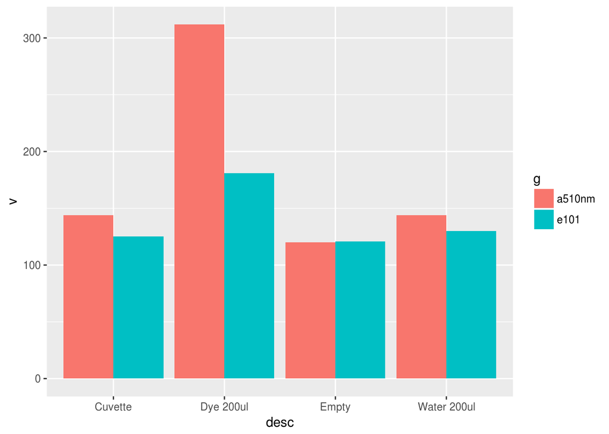

```r
desc <- c(
  "Empty",
  "Cuvette",
  "Water 200ul",
  "Dye 200ul")
v <- c(121, 125, 130, 181, 120, 144, 144, 312)
g <- c(rep("e101", 4), rep("a510nm", 4))

d <- data.frame(desc, v, g)
d %>% ggplot() + geom_col(mapping = aes(y = v, x = desc, group = g, fill = g), position = "dodge")
```

This looks like the A510nm performs better - specifically, it seems to let through more of the fluorescent light.

Then I painted the lid black (the part right opposite the blue LED), and lo and behold, the readout for the empty box changed to 30M (filter installed: A510nm). I adjusted the lens - both sensor and lens mounts are now at +3 on their scales. Using the 3x3 cuvette: Empty: 6M Cuvette, empty: 55M 72ul water: 56M 72ul dye: 111M dye - empty: 56M

Using the 5x5 cuvette: Empty: 7M Cuvette, empty: 43M 100ul water: 43M 200ul water: 41M 100ul dye: 128M 200ul dye: 140M

3x3 cuvette Empty: 7M Cuvette taped, taped side facing sensor, empty: 32 Cuvette taped, open side facing sensor, empty: 30 Cuvette taped, taped side facing sensor, 72ul dye: 87 dye - empty, taped side: 55M

## Dilution series with fluorescent marker dye to compare TSL2591 and TSL235R

The idea here is to make a dilution series of the (cheap) marker dye to test the limits of both sensors - can one sensor detect/quantify lower concentrations of dye than the other?

I will be using the 3x3 cuvette with a 72ul sample volume. Measurements were done in order of decreasing concentration (meaning: highest concentration first, lowest concentration last).

Series:

| Sample ID | Active in ul | Water in ul | Dye ul per 1000ul | Reading @ 72ul | Reading, low to high |
| --- | --- | --- | --- | --- | --- |
| 0 | 0 | 1000 | 0 | 38 |  |
| 1 | dye:100 | 900 | 100 | 103 |  |
| 2 | 1:250 | 250 | 50 | 104 |  |
| 3 | 2:250 | 250 | 25 | 97 |  |
| 4 | 3:125 | 125 | 12.5 | 86 |  |
| 5 | 4:80 | 80 | 6.25 | 80 |  |
| 6 | 5:40 | 40 | 3.125 | 68 | 68 |

```r
v <- c(103, 104, 97, 86, 80, 68)
v - 38
```

```
## [1] 65 66 59 48 42 30
```

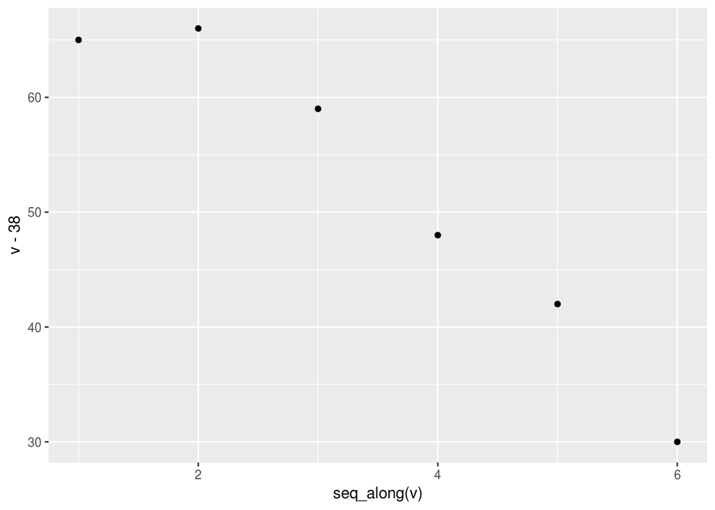

```r
df <- data.frame(values = v)
df %>% ggplot() + geom_point(mapping = aes(x = seq_along(v), y = v - 38))
```

I made some adjustments to the setup: The sensor was out of alignment, and so was the lens, so I adjusted them. After this, the values are as follows:

Empty: 95M Cuvette empty: 125

| Sample ID | Reading |
| --- | --- |
| 6 | 28H |
| 5 | 33H |
| 4 | 22H |
| 3 | 67H |
| 2 | 63H |
| 1 | 54H |

More adjustments - the lens was still out of alignment, quite a lot, so I readjusted it until the light from the chamber visibly hit just the sensor. That brought big changes.

Empty chamber: 25MAX C3x3 72ul Sample 1: 117LOw (meaning: HIGH and MAX did not even return any values) Cuvette3x3 empty: 26 25 109 -1 C3x3 72ul Sample 6: 17 16 67 -1

## Testing the TSL235R sensor

C3x3 72ul Sample 6: Empty chamber: 561 p/s C3x3 Empty: 13 p/s C3x3 72ul Sample 5: 3534 p/s C3x3 72ul Sample 4:

Abandoned test because the sensor was acting wonky - it never seemed to settle on any values but kept slowly increasing and decreasing - maybe remove the capacitor that I added to decouple the power lines as per the suggestion in the sensor’s datasheet?

## Testing with DNA

I will be using a dye stock made from 1ul of 10,000X GelGreen plus 99ul of water. As a DNA source, I will use the 1kB DNA ladder.

```r
sample_vol <- 72 # microliters
sample_stock <- 100 # prepare sample stocks of sample_stock microliters
sample_conc <- c(10, 7.5, 5, 2.5, 1, 0.5, 0.3, 0.2) # list of desired DNA concentrations in micrograms per 100 microliters
dye_vol <- 10 # fixed volume of dye stock for each sample, in ul
mrkr_conc = 20 # micrograms per 100 microliters - the DNA marker is given as 0.2mg/ml
mrkr_vol <- 100 / (mrkr_conc / sample_conc) # volume of DNA marker solution needed for each sample, in ul
water_vol <- sample_stock - dye_vol - mrkr_vol # volume of water to add to each sample
total_dna <- sample_vol / sample_stock * sample_conc # total DNA in a sample of volume sample_vol

options(stringsAsFactors=FALSE)

df <- data.frame(sample_conc, mrkr_vol, water_vol, dye_vol, total_vol = mrkr_vol + water_vol + dye_vol, total_dna, comment = c(""), ug_per_ul = sample_conc / 100)

# manually add some controls - will need to be adjusted if you make changes above
df[nrow(df) + 1,] <- c(0, 0, 90, 10, 100, 0, "No DNA", 0)
df[nrow(df) + 1,] <- c(0, 0, 100, 0, 100, 0, "No DNA no dye", 0)
df[nrow(df) + 1,] <- c(0, 0, 0, 0, 0, 0, "Empty cuvette", 0)
df[nrow(df) + 1,] <- c(0, 0, 0, 0, 0, 0, "Empty chamber", 0)
df
```

```
##    sample_conc mrkr_vol water_vol dye_vol total_vol total_dna
## 1           10       50        40      10       100       7.2
## 2          7.5     37.5      52.5      10       100       5.4
## 3            5       25        65      10       100       3.6
## 4          2.5     12.5      77.5      10       100       1.8
## 5            1        5        85      10       100      0.72
## 6          0.5      2.5      87.5      10       100      0.36
## 7          0.3      1.5      88.5      10       100     0.216
## 8          0.2        1        89      10       100     0.144
## 9            0        0        90      10       100         0
## 10           0        0       100       0       100         0
## 11           0        0         0       0         0         0
## 12           0        0         0       0         0         0
##          comment ug_per_ul
## 1                      0.1
## 2                    0.075
## 3                     0.05
## 4                    0.025
## 5                     0.01
## 6                    0.005
## 7                    0.003
## 8                    0.002
## 9         No DNA         0
## 10 No DNA no dye         0
## 11 Empty cuvette         0
## 12 Empty chamber         0
```

Convenient overview for sample preparation:

```r
df[,c(2,3,4,7)]
```

```
##    mrkr_vol water_vol dye_vol       comment
## 1        50        40      10
## 2      37.5      52.5      10
## 3        25        65      10
## 4      12.5      77.5      10
## 5         5        85      10
## 6       2.5      87.5      10
## 7       1.5      88.5      10
## 8         1        89      10
## 9         0        90      10        No DNA
## 10        0       100       0 No DNA no dye
## 11        0         0       0 Empty cuvette
## 12        0         0       0 Empty chamber
```

I changed the Arduino sketch quite a bit to get all values to be on the same scale. this means we now have huge values, but eh, at least I can sensibly plot them now.

So let’s go again! Results are in file c3x3_2.csv.

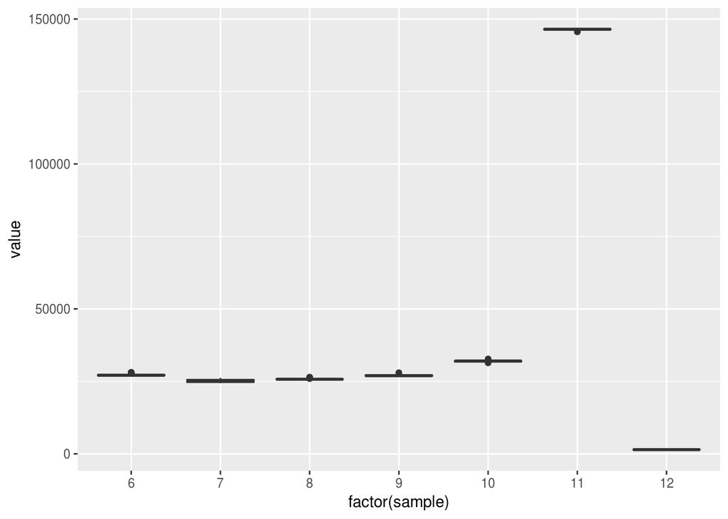

```r
d2 <- read.csv("/home/lisa/projects/biolab/hardware/fluorometer/shd17/hardware/data/c3x3_2_1.csv")
d2 %>% filter(sample == 12 | sample == 11 | sample == 10 | sample == 9 |sample == 8 | sample == 7 | sample == 6 ) %>% group_by(sample) %>% ggplot() + geom_boxplot(mapping = aes(x = factor(sample), y = value, group = factor(sample)))
```

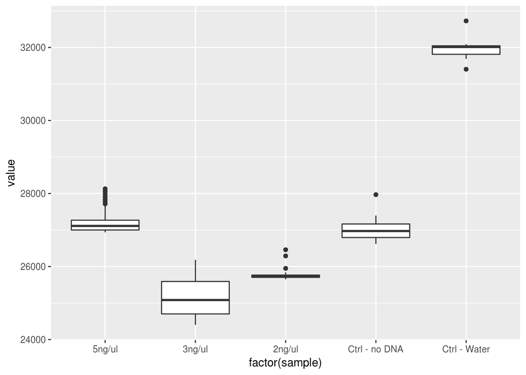

```r
d2 %>% filter(sample == 10 | sample == 9 |sample == 8 | sample == 7 | sample == 6 ) %>% group_by(sample) %>% ggplot() + geom_boxplot(mapping = aes(x = factor(sample), y = value, group = factor(sample))) + scale_x_discrete(labels = rev(c("Ctrl - Water", "Ctrl - no DNA", "2ng/ul", "3ng/ul", "5ng/ul")))
```

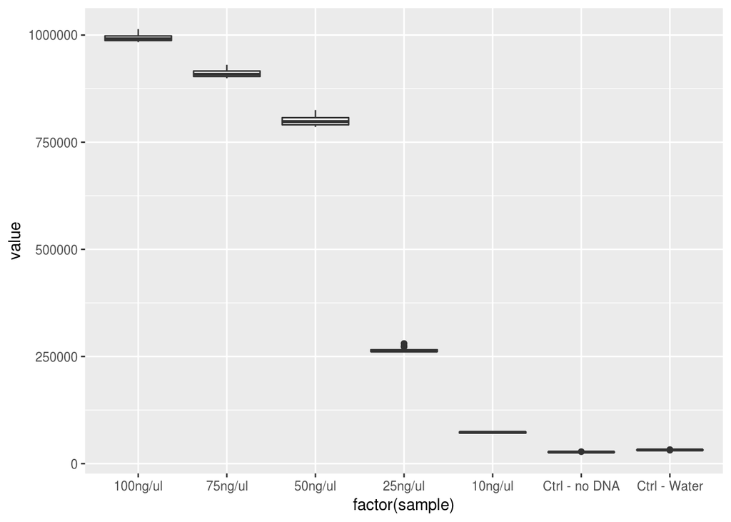

```r
d2 %>% filter(sample == 5 | sample == 4 |sample == 3 | sample == 2 | sample == 1 | sample == 10 | sample == 9) %>% group_by(sample) %>% ggplot() + geom_boxplot(mapping = aes(x = factor(sample), y = value, group = factor(sample)))+ scale_x_discrete(labels = rev(c("Ctrl - Water", "Ctrl - no DNA", "10ng/ul", "25ng/ul", "50ng/ul", "75ng/ul", "100ng/ul")))
```

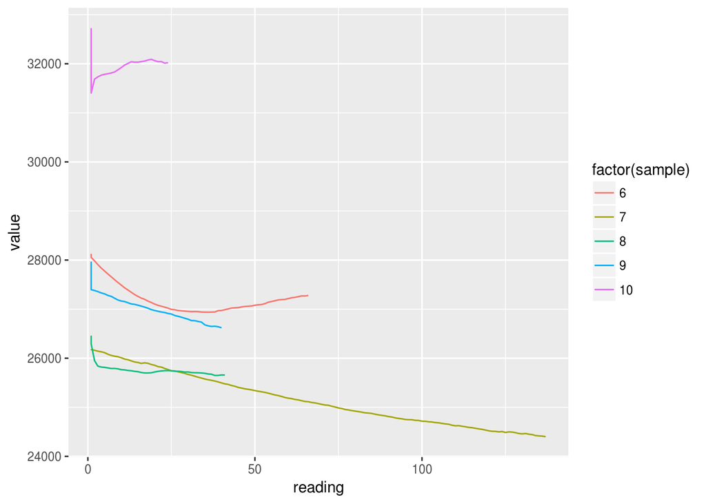

```r
d2 %>% filter(sample == 10 | sample == 9 |sample == 8 | sample == 7 | sample == 6 ) %>% group_by(sample) %>% ggplot() + geom_line(mapping = aes(x = reading, y = value, group = factor(sample), color = factor(sample)))
```

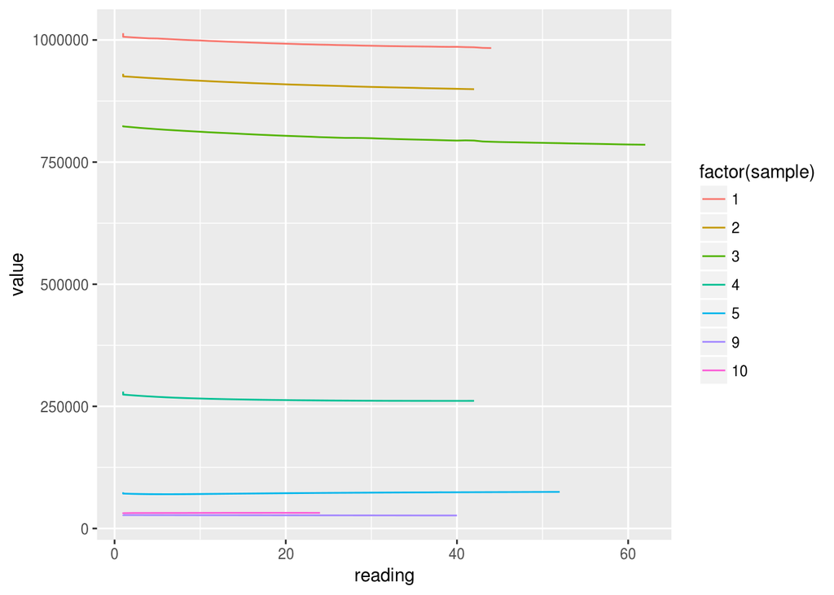

```r
d2 %>% filter(sample == 5 | sample == 4 |sample == 3 | sample == 2 | sample == 1 | sample == 10 | sample == 9) %>% group_by(sample) %>% ggplot() + geom_line(mapping = aes(x = reading, y = value, group = factor(sample), color = factor(sample)))
```

I changed the code again to do readings on demand only and also to output CSV data. I also hooked up the blue LED to a digital pin (instead of the 3.3V supply pin). The LED is now off by default and only gets switched on when measurements are to be taken, and off again after that. This also means that the LED is now running off of 5V with a 56k resistor, so absolute measurements are likely different than before.

A measurement is started by the command “start ” and outputs something like (say, “start test1 3”):

```
test1,1,2478
test1,2,2489
test1,3,2469
```

A measurement can be stopped prematurely by issuing a “stop” command.

All this should make it easier to extract measurements for further processing.

So on to another round! Data is in c3x3_3.csv.

Parameters are: 3x3 cuvette, 72ul sample volume, samples are the same as above. Taking 100 readings per sample.

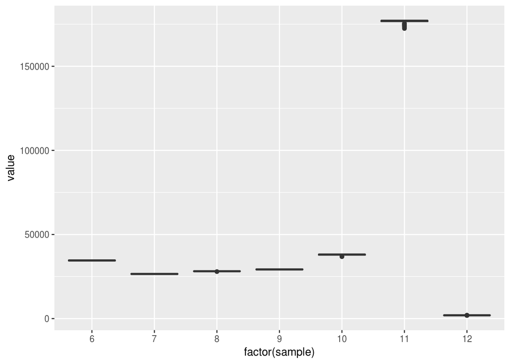

```r
d3 <- read.csv("/home/lisa/projects/biolab/hardware/fluorometer/shd17/hardware/data/c3x3_3.csv")
d3 %>% filter(sample == 12 | sample == 11 | sample == 10 | sample == 9 |sample == 8 | sample == 7 | sample == 6 ) %>% group_by(sample) %>% ggplot() + geom_boxplot(mapping = aes(x = factor(sample), y = value, group = factor(sample)))
```

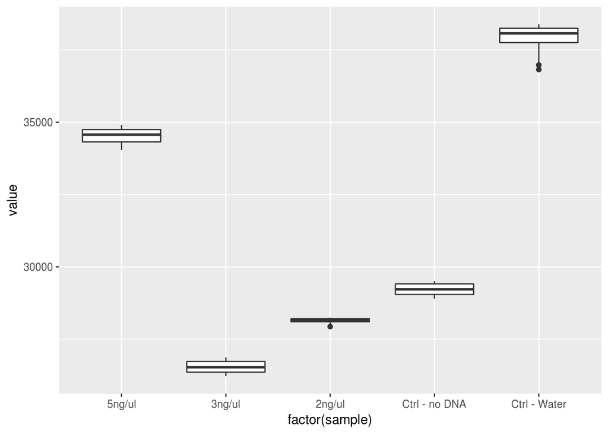

```r
d3 %>% filter(sample == 10 | sample == 9 |sample == 8 | sample == 7 | sample == 6 ) %>% group_by(sample) %>% ggplot() + geom_boxplot(mapping = aes(x = factor(sample), y = value, group = factor(sample))) + scale_x_discrete(labels = rev(c("Ctrl - Water", "Ctrl - no DNA", "2ng/ul", "3ng/ul", "5ng/ul")))
```

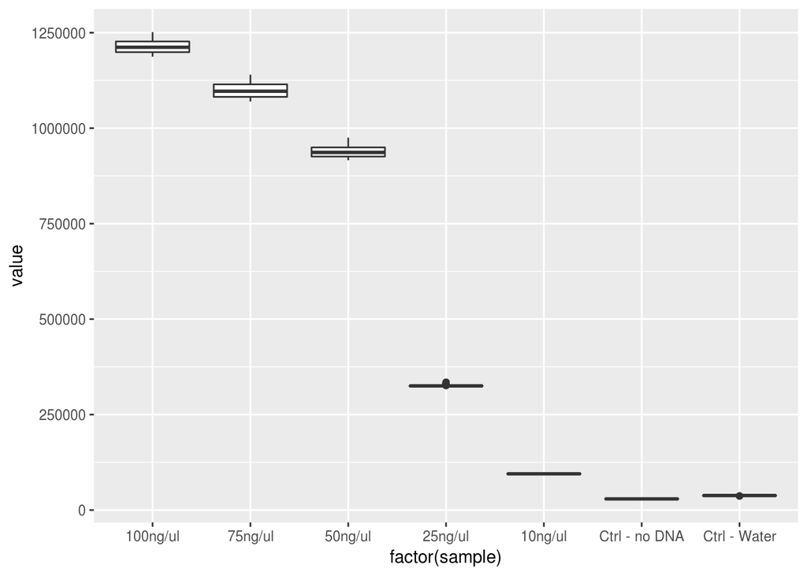

```r
d3 %>% filter(sample == 5 | sample == 4 |sample == 3 | sample == 2 | sample == 1 | sample == 10 | sample == 9) %>% group_by(sample) %>% ggplot() + geom_boxplot(mapping = aes(x = factor(sample), y = value, group = factor(sample)))+ scale_x_discrete(labels = rev(c("Ctrl - Water", "Ctrl - no DNA", "10ng/ul", "25ng/ul", "50ng/ul", "75ng/ul", "100ng/ul")))
```

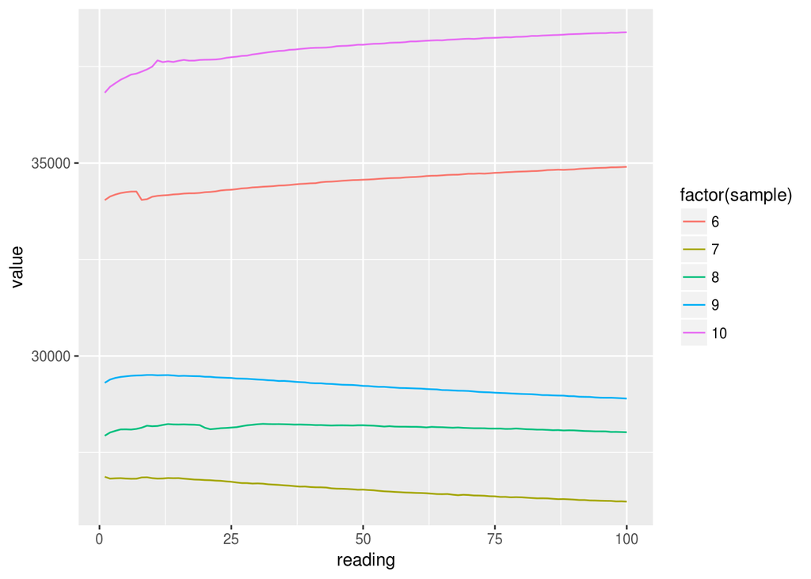

```r
d3 %>% filter(sample == 10 | sample == 9 |sample == 8 | sample == 7 | sample == 6 ) %>% group_by(sample) %>% ggplot() + geom_line(mapping = aes(x = reading, y = value, group = factor(sample), color = factor(sample)))
```

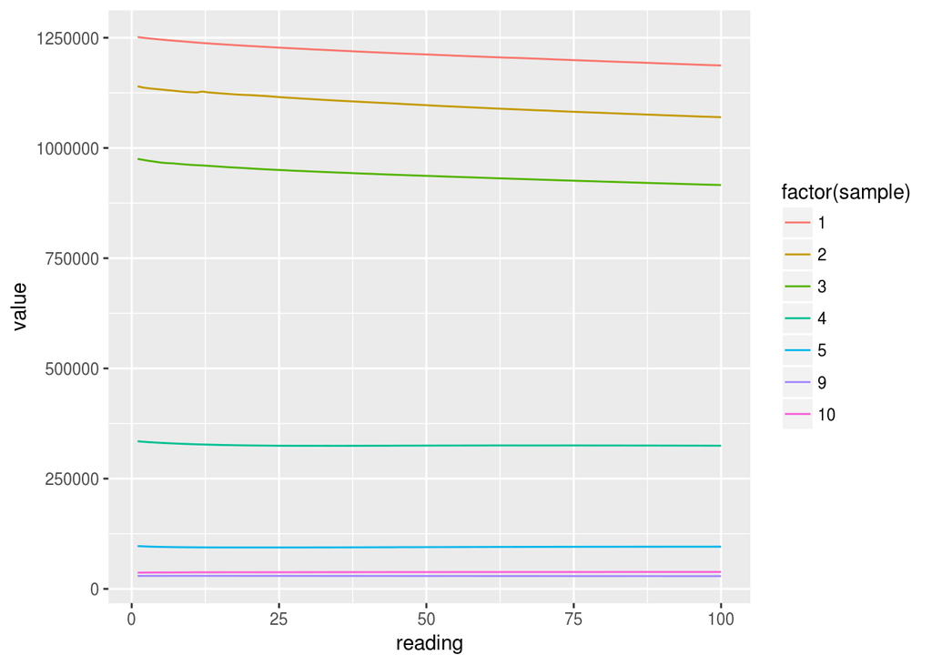

```r
d3 %>% filter(sample == 5 | sample == 4 |sample == 3 | sample == 2 | sample == 1 | sample == 10 | sample == 9) %>% group_by(sample) %>% ggplot() + geom_line(mapping = aes(x = reading, y = value, group = factor(sample), color = factor(sample)))
```

Ok, next, let’s do a test with only 50ul sample volume and see whether this could work as well - that would be great because smaller sample volumes are always good: less reagents needed, less sample wasted. Data is in c3x3_4.csv.

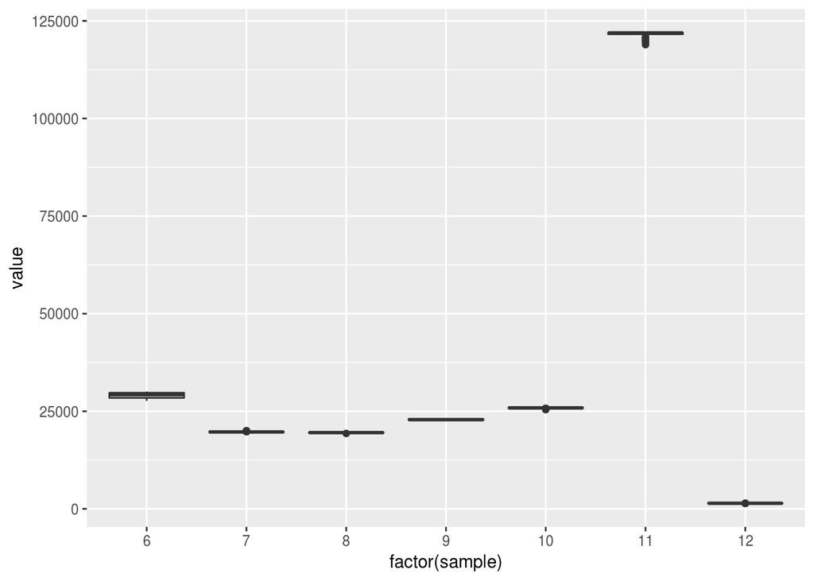

```r
d4 <- read.csv("/home/lisa/projects/biolab/hardware/fluorometer/shd17/hardware/data/c3x3_4.csv")
d4 %>% filter(sample == 12 | sample == 11 | sample == 10 | sample == 9 |sample == 8 | sample == 7 | sample == 6 ) %>% group_by(sample) %>% ggplot() + geom_boxplot(mapping = aes(x = factor(sample), y = value, group = factor(sample)))
```

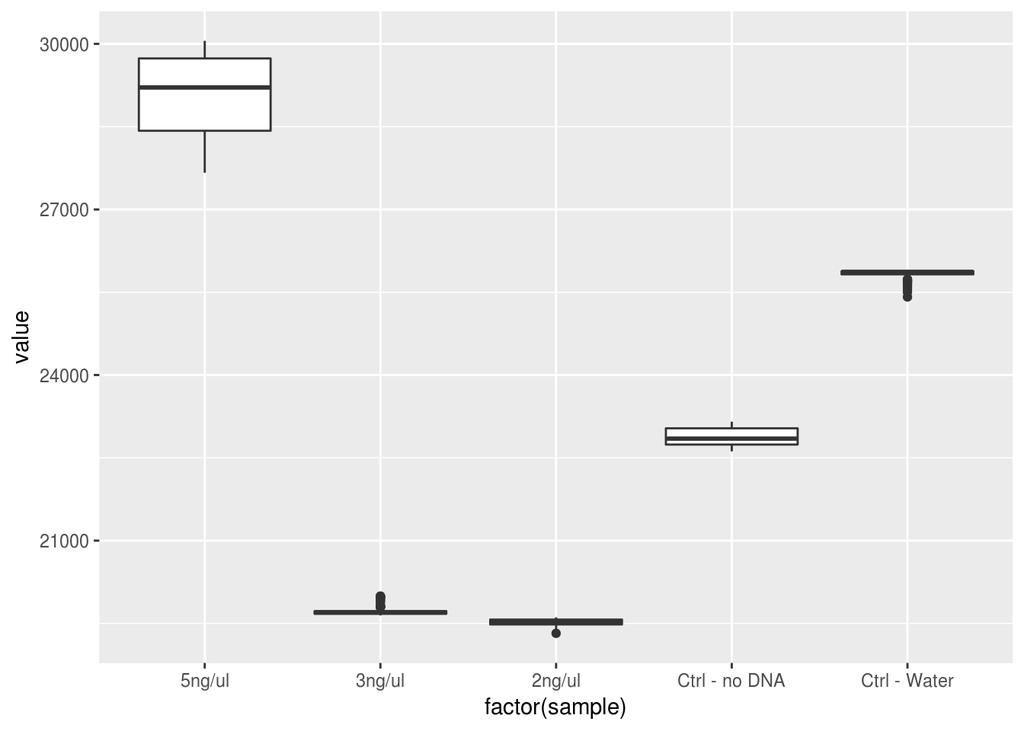

```r
d4 %>% filter(sample == 10 | sample == 9 |sample == 8 | sample == 7 | sample == 6 ) %>% group_by(sample) %>% ggplot() + geom_boxplot(mapping = aes(x = factor(sample), y = value, group = factor(sample))) + scale_x_discrete(labels = rev(c("Ctrl - Water", "Ctrl - no DNA", "2ng/ul", "3ng/ul", "5ng/ul")))
```

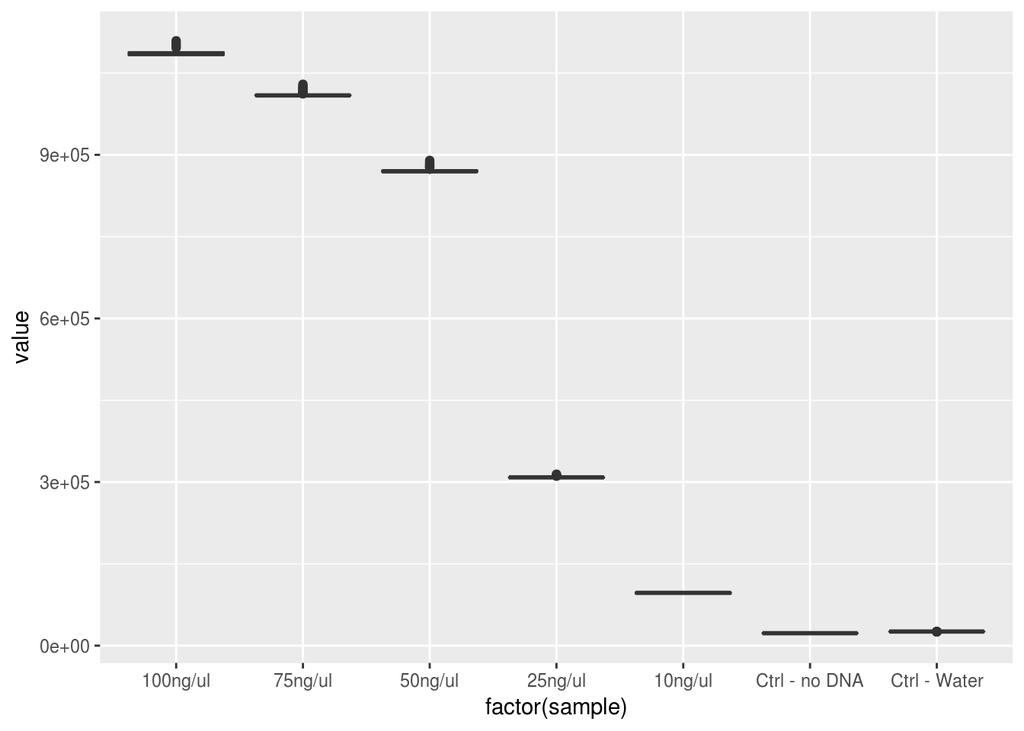

```r
d4 %>% filter(sample == 5 | sample == 4 |sample == 3 | sample == 2 | sample == 1 | sample == 10 | sample == 9) %>% group_by(sample) %>% ggplot() + geom_boxplot(mapping = aes(x = factor(sample), y = value, group = factor(sample)))+ scale_x_discrete(labels = rev(c("Ctrl - Water", "Ctrl - no DNA", "10ng/ul", "25ng/ul", "50ng/ul", "75ng/ul", "100ng/ul")))
```

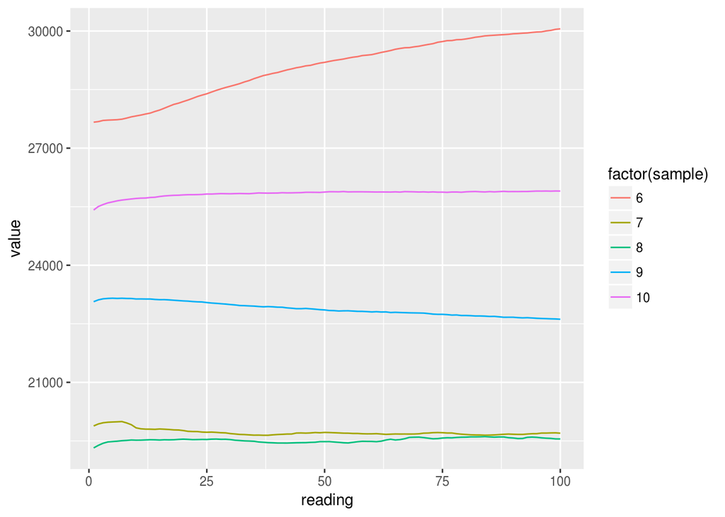

```r
d4 %>% filter(sample == 10 | sample == 9 |sample == 8 | sample == 7 | sample == 6 ) %>% group_by(sample) %>% ggplot() + geom_line(mapping = aes(x = reading, y = value, group = factor(sample), color = factor(sample)))
```

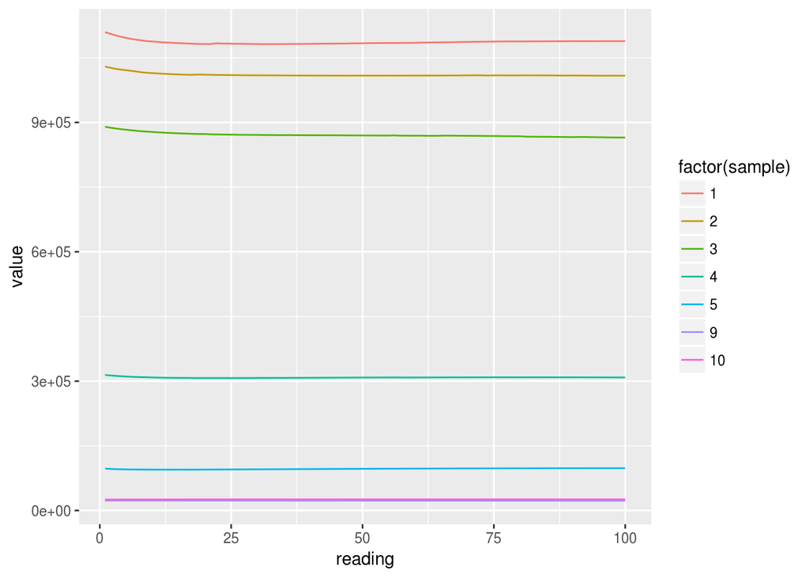

```r
d4 %>% filter(sample == 5 | sample == 4 |sample == 3 | sample == 2 | sample == 1 | sample == 10 | sample == 9) %>% group_by(sample) %>% ggplot() + geom_line(mapping = aes(x = reading, y = value, group = factor(sample), color = factor(sample)))
```

## Dilution series

Instead of calculating and pipetting the different samples individually like I did for the previous measurements, I am now going to make a dilution series. I decided to keep the amount of GelGreen constant for every sample, though. I’ll be treating the GelGreen stock like water for the purpose of calculating concentrations, since it mostly is water. I will be using a dye stock of 0.5ul GelGreen 10,000X plus 49.5ul water. This means it’s the same concentration as before.

This leads to the following steps:

1. Make sample 2-1: 50ul marker + 40ul water. Yields 90ul at 10ug/90ul. Extract 45ul for the dilution and set aside. Add 5ul dye stock to the rest to get 50ul with 5ug of DNA and a concentration of 100ng/ul.
2. Make sample 2-2: Take 45ul from previous step and add 45ul water to make 90ul at 5ug/90ul. Set aside 45ul for the dilution. To the test, add 5ul dye stock to get 50ul with 2.5ug of DNA and a concentration of 50ng/ul.
3. Make sample 2-3: 45ul previous plus 45ul water -> 90ul @ 2.5ug/90ul. Set aside 45ul. To the rest, add 5ul dye stock -> 50ul with 1.25ug DNA and a concentration of 25ng/ul.
4. Make sample 2-4: 45ul previous plus 45ul water -> 90ul @ 1.25ug/90ul. Set aside 45ul. To the rest, add 5ul dye stock -> 50ul with 0.625ug DNA and a concentration of 12.5ng/ul.
5. Make sample 2-5: 45ul previous plus 45ul water -> 90ul @ 0.625ug/90ul. Set aside 45ul. To the rest, add 5ul dye stock -> 50ul with 0.3125ug DNA and a concentration of 6.25ng/ul.
6. Make sample 2-6: 45ul previous plus 45ul water -> 90ul @ 0.3125ug/90ul. Add 10ul dye stock -> 100ul with 0.3125ug DNA and a concentration of 3.125ng/ul.

Measurements are in c3x3_5.csv. For reasons of fraggledom, the sample volume is 45ul.

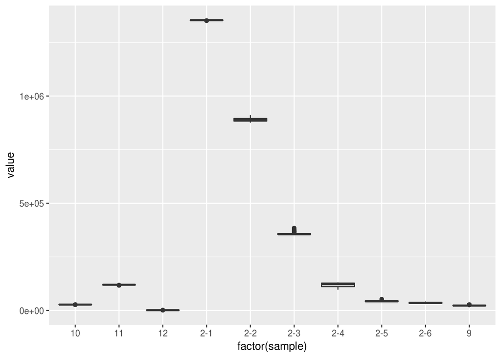

```r
d5 <- read.csv("/home/lisa/projects/biolab/hardware/fluorometer/shd17/hardware/data/c3x3_5.csv")
d5 %>% group_by(sample) %>% ggplot() + geom_boxplot(mapping = aes(x = factor(sample), y = value, group = factor(sample)))
```

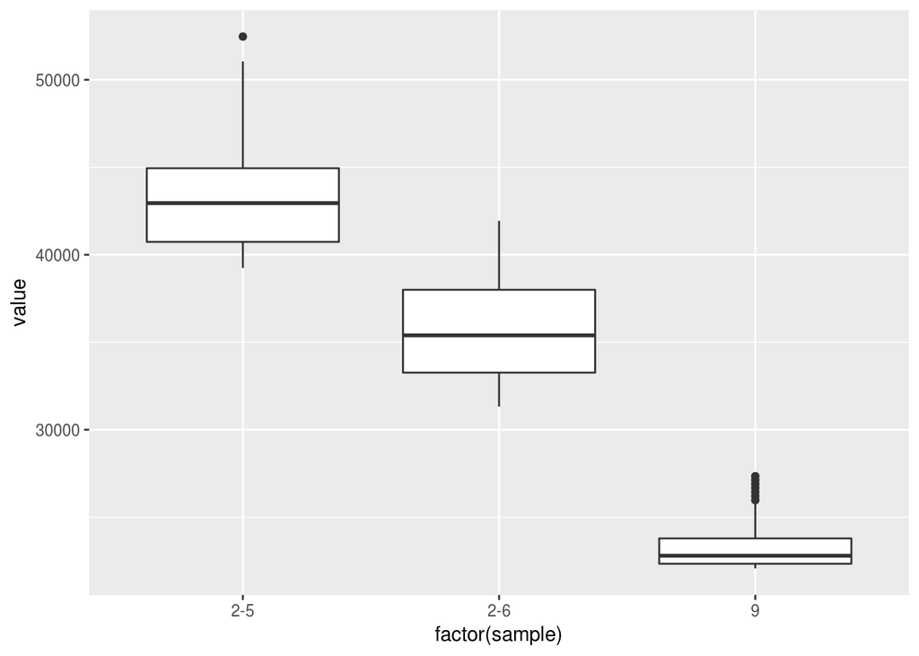

```r
d5 %>% filter(sample == "2-6" | sample == "2-5" | sample == "9") %>% group_by(sample) %>% ggplot() + geom_boxplot(mapping = aes(x = factor(sample), y = value, group = factor(sample)))
```

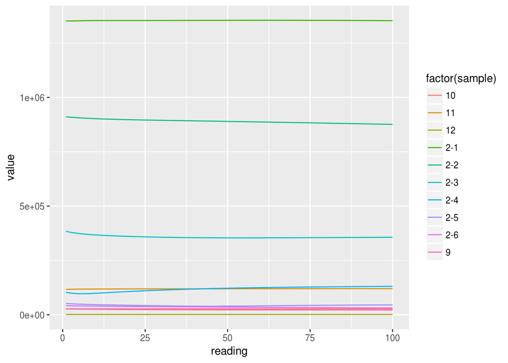

```r
d5 %>% group_by(sample) %>% ggplot() + geom_line(mapping = aes(x = reading, y = value, group = factor(sample), color = factor(sample)))
```

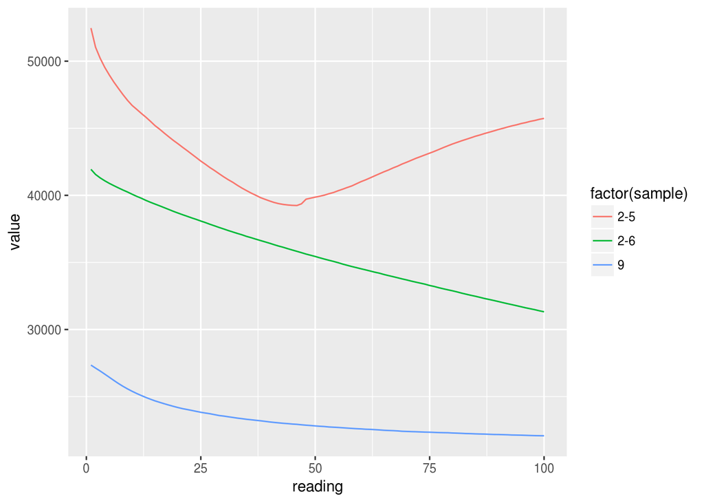

```r
d5 %>% filter(sample == "2-6" | sample == "2-5" | sample == "9") %>% group_by(sample) %>% ggplot() + geom_line(mapping = aes(x = reading, y = value, group = factor(sample), color = factor(sample)))
```